# dCovTS: Distance Covariance/Correlation for Time Series

The distance covariance function is a new measure of dependence between random vectors. We drop the assumption of iid data to introduce distance covariance for time series. The R package *dCovTS* provides functions that compute and plot distance covariance and correlation functions for both univariate and multivariate time series. Additionally it includes functions for testing serial independence based on distance covariance. This paper describes the theoretical background of distance covariance methodology in time series and discusses in detail the implementation of these methods with the R package *dCovTS*.

Maria Pitsillou (Department of Mathematics & Statistics, University of Cyprus) , Konstantinos Fokianos (Department of Mathematics & Statistics, University of Cyprus)  
2016-10-21

## 1 Introduction

There has been a considerable recent interest in measuring dependence by employing the concept of the distance covariance function. Székely, M. L. Rizzo, and N. K. Bakirov (2007) initially introduced the distance covariance as a new measure of dependence defined as the weighted $L_2$-norm between the joint characteristic function of two random vectors of arbitrary, but not necessarily of equal dimensions, and their marginal characteristic functions. However, the idea of using distance covariance for detecting independence can be also found in some early work by Feuerverger (1993). He considered measures of this form, with the main differences being the restriction to the univariate case and the choice of the weight function. Since (Székely, M. L. Rizzo, and N. K. Bakirov 2007) work, there has been a wide range of studies extending the distance covariance definition and methodology in various topics; see Gretton, K. Fukumizu, and B. K. Sriperumbudur (2009) and Josse and S. Holmes (2014) and the references therein for a nice review.

(Székely, M. L. Rizzo, and N. K. Bakirov 2007) distance covariance methodology is based on the assumption that the underlying data are iid. However, this assumption is often violated in many practical problems. Remillard (2009) proposed to extend the distance covariance methodology to a time series context in order to measure serial dependence. There have been few works on how to develop a distance covariance methodology in the context of time series (Zhou 2012; Dueck, D. Edelmann, T. Gneiting, and D. Richards 2014; Davis, M. Matsui, T. Mikosch, and P. Wan 2016). Motivated by the work of Székely, M. L. Rizzo, and N. K. Bakirov (2007), Zhou (2012) recently defined the so-called auto-distance covariance function (ADCV) - and its rescaled version, the so-called auto-distance correlation function (ADCF), for a strictly stationary multivariate time series. Compared to the classical Pearson autocorrelation function (ACF) which measures the strength of linear dependencies and can be equal to zero even when the variables are related, ADCF vanishes only in the case where the observations are independent. However, Zhou (2012) studied the asymptotic behavior of ADCV at a fixed lag order. Fokianos and M. Pitsillou (2016a) relaxed this assumption and constructed a univariate test of independence by considering an increasing number of lags following (Hong 1999) generalized spectral domain methodology. Although the proposed methodology is for univariate processes, it can be extended for multivariate processes.

Zhou (2012) developed a distance covariance methodology for multivariate time series, but he did not explore the interrelationships between the various time series components. Fokianos and M. Pitsillou (2016b) made this possible by defining the matrix version of pairwise auto-distance covariance and correlation functions. In particular, they construct multivariate tests of independence based on these new measures in order to identify whether there is some inherent nonlinear interdependence between the component series.

The [*energy*](https://CRAN.R-project.org/package=energy) (Rizzo and G. J. Szekely 2014) package for R is a package that involves a wide range of functions for the existing distance covariance methodology. However, there is no package for the aforementioned distance covariance methodology in time series. Thus, we aim at filling this gap by publishing an R-package named *dCovTS*. In this first version of the package, we provide functions that compute and plot ADCV and ADCF using the functions `dcov()` and `dcor()` respectively from *energy* package. The new testing methodology proposed by Fokianos and M. Pitsillou (2016a,b) is also included in the package.

The structure of the paper is as follows. In the first two sections we introduce the theoretical background of distance covariance function for both univariate and multivariate time series respectively. In the next section, we briefly state the main results about the asymptotic properties of distance covariance function. The proposed testing methodology for both univariate and multivariate time series are also described. Empirical $p$-values of the tests and empirical critical values for the distance correlation plots are computed via the wild bootstrap methodology (Dehling and T. Mikosch 1994; Shao 2010; Leucht and M. H. Neumann 2013b) which is explained in the corresponding section. The implementation section demonstrates the usage of the package with two real data examples. Lastly, we give some concluding remarks and some further points for future extensions of the *dCovTS* package.

## 2 Distance covariance function

Denote a univariate strictly stationary time series by $\{X_t, t \in \mathbb{Z}\}$. Motivated by Székely, M. L. Rizzo, and N. K. Bakirov (2007) and Zhou (2012), we define the distance covariance function as a function of the joint and marginal characteristic functions of the pair $(X_t, X_{t+j})$. Denote by $\phi_{j}(u,v)$ the joint characteristic function of $X_t$ and $X_{t+j}$; that is
$$\label{eq:phi}
\phi_{j}(u,v) = E\Bigl[\exp\Bigl(i\left(uX_t + vX_{t+j}\right)\Bigr)\Bigr], ~~~~ j= 0, \pm 1, \pm 2, \dots, \nonumber \tag{1}$$
and the marginal characteristic functions of $X_t$ and $X_{t+j}$ as $\phi(u) := \phi_{j}(u,0)$ and $\phi(v) := \phi_{j}(0,v)$ respectively, where $(u,v) \in \mathbb{R}^2$, and $i^2=-1$. For a strictly stationary $\alpha$-mixing univariate time series, Hong (1999) defined a new measure of dependence between the joint characteristic function of $X_t$ and its lagged observation $X_{t+j}$ and the product of their marginals, namely
$$\label{eq:sigma}
\sigma_j(u,v) = \phi_{j}(u,v) - \phi(u)\phi(v), ~~~~ j= 0, \pm 1, \pm 2, \dots, \tag{2}$$
where $(u,v) \in \mathbb{R}^2$. Considering the property that the joint characteristic function factorizes under independence of $X_t$ and $X_{t+j}$, $\sigma_{j}(u,v)$ equals 0 if and only if $X_t$ and $X_{t+j}$ are independent. Thus, compared to the classical autocorrelation function (ACF), $\sigma_j(\cdot,\cdot)$ can capture all pairwise dependencies including those with zero autocorrelation. The auto-distance covariance function (ADCV), $V_X(j)$, between $X_t$ and $X_{t+j}$ is then defined as the square root of
$$\label{eq:dcov}
V_X^2(j) = \int_{\mathbb{R}^2}{\left|\sigma_j(u,v)\right|^2 d\mathcal{W}(u,v)}, ~~~~ j=0, \pm 1, \pm 2, \dots \tag{3}$$
where $\mathcal{W}(\cdot,\cdot)$ is a positive weight function for which the above integral exists.

Although Hong (1999) suggests the use of an arbitrary integrable weight function, $\mathcal{W}(\cdot,\cdot)$, we propose the use of a non-integrable weight function, i.e.
$$\label{eq:weight}
\mathcal{W}(u,v) = \mathcal{W}_0(u) \mathcal{W}_0(v)=\frac{1}{\pi \left|u\right|^2} \frac{1}{\pi \left|v\right|^2}, ~~~ (u,v) \in \mathbb{R}^2 \tag{4}$$
which avoids missing any potential dependence among observations (Székely, M. L. Rizzo, and N. K. Bakirov 2007 2771). Rescaling (3), one can define the auto-distance correlation function (ADCF) as the positive square root of
$$\label{eq:dcor}
R_X^2(j) = \frac{V_X^2(j)}{V_X^2(0)}, ~~~~~ j=0, \pm 1, \pm 2, \dots \tag{5}$$
for $V_X^2(0) \neq 0$ and zero otherwise. Székely, M. L. Rizzo, and N. K. Bakirov (2007) showed that by applying a non-integrable weight function, like (4), ADCF is scale invariant and is not zero under dependence.

The empirical ADCV, $\widehat{V}_X(\cdot)$, is the non-negative square root of
$$\label{eq:Vhat}
\widehat{V}_X^2(j) = \frac{1}{(n-j)^2}\sum_{r,l=1+j}^{n}{A_{rl}B_{rl}}, ~~~~~ 0 \leq j \leq (n-1) \tag{6}$$
and $\widehat{V}_X^2(-j) = \widehat{V}_X^2(j)$, for $-(n-1) \leq j < 0$, where $A=A_{rl}$ and $B=B_{rl}$ are Euclidean distance matrices given by
$$A_{rl} = a_{rl} - \bar{a}_{r.} - \bar{a}_{.l} + \bar{a}_{..},$$
with $a_{rl}=\left|X_r-X_l\right|$, $\bar{a}_{r.}=\Bigl(\sum_{l=1+j}^{n}{a_{rl}}\Bigr)/(n-j)$, $\bar{a}_{.l}=\Bigl(\sum_{r=1+j}^{n}{a_{rl}}\Bigr)/(n-j)$, $\bar{a}_{..}=\Bigl(\sum_{r,l=1+j}^{n}{a_{rl}}\Bigr)/(n-j)^2$. $B_{rl}$ is defined analogously in terms of $b_{rl}=\left|Y_r-Y_l\right|$, where $Y_t \equiv X_{t+j}$. Székely and M. L. Rizzo (2014) proposed an unbiased version of the sample distance covariance. In the context of time series data this is given by
$$\label{eq:Vhat2}
\widetilde{V}^2_X(j) = \frac{1}{(n-j)(n-j-3)}\sum_{r\neq l}{\widetilde{A}_{rl}\widetilde{B}_{rl}}, \tag{7}$$
for $n > 3$, where $\widetilde{A}_{rl}$ is the $(r,l)$ element of the so-called $\mathcal{U}$-centered matrix $\widetilde{A}$, defined by

$$\widetilde{A}_{rl} = \left\{
\begin{array}{ll}
\displaystyle a_{rl} - \frac{1}{n-j-2}\sum_{t=1+j}^{n}{a_{rt}}-\frac{1}{n-j-2}\sum_{s=1+j}^{n}{a_{sl}+\frac{1}{(n-j-1)(n-j-2)}\sum_{t,s=1+j}^{n}{a_{ts}}}, & \hbox{$r \neq l$;} \\
0, & \hbox{$r=l$.}
\end{array}
\right.$$

The empirical ADCF, $\widehat{R}_X(j)$ (or its unbiased version, $\widetilde{R}_X(j)$), can be obtained by replacing (6) (or (7)) into (5). The functions `ADCV()` and `ADCF()` in *dCovTS* return the empirical quantities $\widehat{V}_X(\cdot)$ and $\widehat{R}_X(\cdot)$ respectively. Using the same functions with argument `unbiased=TRUE`, the results correspond to the unbiased sqaured quantities $\widetilde{V}^2_X(\cdot)$ and $\widetilde{R}^2_X(\cdot)$. Note that the default option has been set to `unbiased=FALSE` (corresponding to (6)).

## 3 Distance covariance matrix

We denote by $\{\textbf{X}_t: t=0,\pm 1, \pm 2, \dots\}$ a $d$-dimensional time series process, with components $\{X_{t;i}\}_{i=1}^d$. The characteristic functions can be defined in analogous way as in the univariate case. In particular, the joint characteristic function of $X_{t;r}$ and $X_{t+j;m}$ is given by
$$\phi_{j}^{(r,m)}(u,v) = E\Bigl[\exp\Bigl(i\left(uX_{t;r} + vX_{t+j;m}\right)\Bigr)\Bigr], ~~~~ j = 0, \pm 1, \pm 2, \dots$$
and the marginal characteristic functions of $X_{t;r}$ and $X_{t+j;m}$ by $\phi^{(r)}(u) := \phi_{j}^{(r,m)}(u,0)$ and $\phi^{(m)}(v) := \phi_{j}^{(r,m)}(0,v)$ respectively, with $(u,v) \in \mathbb{R}^2$, $r,m=1, \dots d$ and $i^2=-1$. The pairwise ADCV between $X_{t;r}$ and $X_{t+j;m}$ is denoted by $V_{rm}(j)$ and it is defined as the non-negative square root of
$$V_{rm}^2(j) = \int_{\mathbb{R}^2}{\left|\sigma_{j}^{(r,m)}(u,v)\right|^2\mathcal{W}(u,v)dudv}, ~~~~ j = 0, \pm 1, \pm 2, \dots$$
where $\mathcal{W}(\cdot,\cdot)$ is given by (4) and $\sigma_{j}^{(r,m)}(u,v)$ is similarly defined as in the univariate case, namely
$$\sigma_{j}^{(r,m)}(u,v) = \phi_{j}^{(r,m)}(u,v) - \phi^{(r)}(u)\phi^{(m)}(v).$$
Clearly, $V_{rm}^2(j) \geq 0$, $\forall ~~ j$ and $X_{t;r}$ and $X_{t+j;m}$ are independent if and only if $V_{rm}^2(j) = 0$. The ADCV matrix, $V(j)$, is then defined by
$$\label{eq:V}
V(j) = \Bigl[ V_{rm}(j) \Bigr]_{r,m=1}^d, ~~~~ j = 0, \pm 1, \pm 2, \dots \tag{8}$$

The pairwise ADCF between $X_{t;r}$ and $X_{t+j;m}$, $R_{rm}(j)$, is a coefficient that lies in the interval $[0,1]$ and also measures dependence and is defined as the positive square root of
$$\label{eq:rrmk}
R^2_{rm}(j) = \frac{V_{rm}^2(j)}{\sqrt{V^2_{rr}(0)}\sqrt{V^2_{mm}(0)}}, \tag{9}$$
for $V_{rr}(0)V_{mm}(0) \neq 0$ and zero otherwise. The ADCF matrix of $\textbf{X}_t$, is then defined as
$$R(j) = \Bigl[R_{rm}(j)\Bigr]_{r,m=1}^{d}, ~~~~ j = 0, \pm 1, \pm 2, \dots$$

$V_{rm}(j)$ measures the dependence of $X_{t;r}$ on $X_{t+j;m}$. In general, $V_{rm}(j) \neq V_{mr}(j)$ for $r \neq m$, since they measure different dependence structure between the series $\{X_{t;r}\}$ and $\{X_{t;m}\}$ for all $r,m=1, 2, \dots, d$. Thus, $V(j)$ and $R(j)$ are non-symmetric matrices. Moreover, because of the assumed stationarity and relation $\mbox{Cov}(x,y) = \mbox{Cov}(y,x)$, $V(j) = V'(-j)$ and consequently $R(j) = R'(-j)$. More properties of these new defined functions can be found in Fokianos and M. Pitsillou (2016b).

Estimation of $V_{rm}^2(\cdot)$ can be dealt in a similar way as in the univariate case. In particular, let first $Y_{t;m} \equiv X_{t+j;m}$. Based on the sample $\{(X_{t;r},Y_{t;m}):t=1+j, \dots, n\}$, we define the Euclidean distance matrices by $(a_{ts}^r)=\left|X_{t;r}-X_{s;r}\right|$ and $(b_{ts}^m)=\left|Y_{t;m}-Y_{s;m}\right|$ and the centered distance matrices by
$$\begin{aligned}
A_{ts}^r & = a_{ts}^r - \bar{a}_{t.}^r - \bar{a}_{.s}^r + \bar{a}_{..}^r, \nonumber \\
B_{ts}^m & = b_{ts}^m - \bar{b}_{t.}^m - \bar{b}_{.s}^m + \bar{b}_{..}^m, \nonumber
\end{aligned}$$
where the quantities in the right hand side are defined analogously as those defined in the univariate case. The biased estimator of $V_{rm}^2(\cdot)$ is then given by
$$\label{eq:Vrmest2}
\widehat{V}_{rm}^2(j) = \left\{
\begin{array}{ll}
\displaystyle \frac{1}{(n-j)^2}\sum_{t,s=1+j}^{n}{A_{ts}^rB_{ts}^m}, & \hbox{$0 \leq j \leq (n-1)$;} \\
\displaystyle \frac{1}{(n+j)^2}\sum_{t,s=1}^{n+j}{A_{ts}^rB_{ts}^m}, & \hbox{$-(n-1) \leq j < 0$.}
\end{array}
\right. \tag{10}$$
Analogously to (7), an unbiased estimator of $\widehat{V}_{rm}^2(\cdot)$ is given by

$$\label{eq:Vrmest3}
\widetilde{V}_{rm}^2(j) = \left\{
\begin{array}{ll}
\displaystyle \frac{1}{(n-j)(n-j-3)}\sum_{t,s=1+j}^{n}{\widetilde{A}_{ts}^r\widetilde{B}_{ts}^m}, & \hbox{$0 \leq j \leq (n-1)$;} \\
\displaystyle \frac{1}{(n+j)(n+j-3)}\sum_{t,s=1}^{n+j}{\widetilde{A}_{ts}^r\widetilde{B}_{ts}^m}, & \hbox{$-(n-1) \leq j < 0$,}
\end{array}
\right. \tag{11}$$
where $\widetilde{A}_{ts}^{r}$ are computed appropriately.

The sample ADCV matrix, $\widehat{V}(\cdot)$, is then obtained by replacing its elements by the positive square root of (10) and can be calculated from *dCovTS* using the `mADCV()` function. The estimator based on (11), $\widetilde{V}(\cdot)$, is obtained from *dCovTS* using the argument `unbiased = TRUE`. The package also gives the sample ADCF matrix $\widehat{R}(\cdot)$ (function `mADCF()`) which is obtained after replacing (10) (or $\widetilde{R}_X(j)$ which is based on (7)) into (9). The distance correlation plots for both univariate and multivariate time series are obtained by the `ADCFplot()` and `mADCFplot()` functions respectively, where the shown critical values (blue dotted horizontal line) are computed by employing bootstrap methodology described in the appropriate section. Recall that these are computed by using the biased definition of distance covariance and correlation.

## 4 Consistency and asymptotic distribution of distance covariance

Consider first the univariate case. For a strictly stationary and $\alpha$-mixing process $X_t$, with $E\left|X_t\right| < \infty$, then for all $j=0, \pm 1, \pm 2, \dots$
$$\widehat{V}_X^2(j) \rightarrow V_X^2(j)$$
almost surely, as $n \rightarrow \infty$. A detailed proof of this result can be found in Fokianos and M. Pitsillou (2016a). Under mild conditions, Zhou (2012) obtained the weak consistency of $\widehat{V}_X^2(\cdot)$ and its asymptotic distribution at a fixed lag, but under alternative mixing conditions.

In addition, Fokianos and M. Pitsillou (2016b) showed that for a $d$-dimensional strictly stationary and ergodic time series process $\{\textbf{X}_t\}$ with $E\left|X_{t;r}\right| < \infty$ for $r=1, \dots, d$, then for all $j=0, \pm 1, \pm 2, \dots$
$$\widehat{V}(j) \rightarrow V(j)$$
almost surely as $n \rightarrow \infty$. Under pairwise independence, the empirical pairwise ADCV is a degenerate $V$-statistic of order two with a measurable kernel function that is symmetric, continuous and positive semidefinite Then
$$\label{eq:distribution}
(n-j)\widehat{V}_{X}^2(j) \rightarrow Z:=\sum_{k}{\lambda_kZ_k^2} \tag{12}$$
in distribution, as $n \rightarrow \infty$, where $\{Z_k\}$ is an iid sequence of $N(0,1)$ random variables, and $(\lambda_k)$ is a sequence of nonzero eigenvalues. A similar result showing the limiting distribution of $\widehat{V}_{rm}(\cdot)$ can be obtained by replacing $\widehat{V}_{X}(\cdot)$ by $\widehat{V}_{rm}(\cdot)$ in (12).

## 5 Testing for pairwise dependence in univariate time series

As shown in the previous section, the asymptotic distribution of distance covariance is derived at a fixed lag, for both univariate and multivariate time series. Fokianos and M. Pitsillou (2016a,b) constructed the asymptotic behavior of distance covariance considering an increasing number of lags by employing (Hong 1999) generalized spectral domain methodology. Hong (1999) highlighted that standard spectral density approaches become inappropriate for non-Gaussian and nonlinear processes with zero autocorrelation. Considering a univariate strictly stationary $\alpha$-mixing process, he proposed the generalized spectral density, which is the Fourier transform of $\sigma_j(u,v)$ defined in (2), given by
$$f(\omega,u,v) = \frac{1}{2\pi} \sum_{j=-\infty}^{\infty}{\sigma_j(u,v)e^{-ij\omega}}.$$
Under the null hypothesis of independence, the corresponding null density is given by
$$f_0(\omega,u,v) = \frac{1}{2\pi}\sigma_0(u,v), ~~~~ \omega \in [-\pi,\pi].$$
Any deviation of $f$ from $f_0$ is a strong evidence of pairwise dependence. Thus, Hong (1999) compares the (Parzen 1957) kernel-type estimators $\hat{f}(\omega,u,v)$ and $\hat{f}_0(\omega,u,v)$ via an $L_2$-norm resulting in a test statistic of the form
$$\label{eq:Tn2}
T_n^{(2)} = \int_{\mathbb{R}^2}{\sum_{j=1}^{n-1}{(n-j)k^2(j/p)\left|\hat{\sigma}_j(u,v)\right|} d \mathcal{W}(u,v)}, \tag{13}$$
where $\mathcal{W}(\cdot,\cdot): \mathbb{R}^2 \rightarrow \mathbb{R}$ is an arbitrary nondecreasing function with bounded total variation, $p$ is a bandwidth of the form $p = cn^{\lambda}$ for $c > 0$ $\lambda \in (0,1)$ and $k(\cdot)$ is a Lipschitz-continuous kernel function satisfying the following assumption:

##### assumption

$k: \mathbb{R} \rightarrow [-1,1]$ is symmetric and is continuous at $0$ and at all but a finite number of points, with $k(0)=1$, $\int_{-\infty}^{\infty}{k^2(z)dz} < \infty$ and $\left|k(z)\right| \leq C \left|z\right|^{-b}$ for large $z$ and $b > 1/2$.

The function `kernelFun()` in *dCovTS* computes a number of such kernel functions including the truncated (default option), Bartlett, Daniell, QS and Parzen kernels.

Fokianos and M. Pitsillou (2016a) proposed a portmanteau type statistic based on ADCV
$$\label{eq:Tn}
T_n = \sum_{j=1}^{n-1}{(n-j)k^2(j/p)\widehat{V}^2_X(j)}. \tag{14}$$
Under the null hypothesis that the data are iid and some further assumptions about the kernel function $k(\cdot)$, the standardized version of $T_n$ follows a $N(0,1)$ asymptotically, and it is consistent. The authors also considered a similar test statistic based on ADCF
$$\label{eq:Tndcor}
\sum_{j=1}^{n-1}{(n-j)k^2(j/p)\widehat{R}^2_X(j)}. \tag{15}$$
The function `UnivTest` from *dCovTS* package performs univariate tests of independence based on (14) and its rescaled version (15), using the arguments `testType = "covariance"` and `testType = "correlation"` respectively.

## 6 Testing for pairwise dependence in multivariate time series

Following a similar methodology described in the previous section, Fokianos and M. Pitsillou (2016b) suggested a test statistic suitable for testing pairwise independence in a multivariate time series framework. The proposed test statistic is based on the ADCV matrix (8), and it is given by
$$\label{eq:tildeTn}
\widetilde{T}_n = \sum_{j=1}^{n-1}{(n-j)k^2(j/p) \mbox{tr}{\widehat{V}^*(j)\widehat{V}(j)}}. \tag{16}$$

where $k(\cdot)$ is a univariate kernel function satisfying Assumption 1, $p$ is a bandwidth as described before. Moreover, $\widehat{V}^{*}(\cdot)$ denotes the complex conjugate matrix of $\widehat{V}(\cdot)$ and $\mbox{tr}(A)$ denotes the trace of the matrix $A$. The authors formed the statistic (16) in terms of the ADCF matrix as follows

$$\label{eq:barTn}
\overline{T}_n = \sum_{j=1}^{n-1}{(n-j)k^2(j/p) \mbox{tr}{\widehat{V}^*(j)\widehat{D}^{-1}\widehat{V}(j)\widehat{D}^{-1}}}, \tag{17}$$

where $D = diag\{V_{rr}(0), r = 1, 2, \dots, d\}$. Under the null hypothesis of independence and some further assumptions about the kernel function $k(\cdot)$, the standardized version of the test statistics $\widetilde{T}_n$ and $\overline{T}_n$ given in (16) and (17) were proved to follow $N(0,1)$ asymptotically and they are consistent. The multivariate tests of independence based on $\widetilde{T}_n$ and $\overline{T}_n$ are performed via `mADCVtest()` and `mADCFtest()` respectively in *dCovTS* package.

## 7 Bootstrap methodology

To examine the asymptotic behavior of the proposed test statistics, a resampling method is proposed. First, recall that all test statistics $T_n$, $\widetilde{T}_n$ and $\overline{T}_n$ of equations (14), (16) and (17) respectively, are functions of degenerate $V$- statistics of order two. Dehling and T. Mikosch (1994) proposed wild bootstrap techniques to approximate the distribution of degenerate $U$-statistics for the case of iid data. Recently, Leucht and M. H. Neumann (2013a,b) suggested the use of a new variant of dependent wild bootstrap (Shao 2010) to approximate the limit distribution of degenerate $U$- and $V$-statistics for dependent data. The method relies on generating auxiliary random variables $\left(W_{tn}^*\right)_{t=1}^{n-j}$. Shao (2010) highlighted that the methodology of wild bootstrap for time series extends that of Wu (1986) by allowing the auxiliary random variables $W_{tn}^{*}$ to be dependent. In particular, Leucht and M. H. Neumann (2013b) proposed to generate the sequence $W_{tn}^{*}$ by a first order autoregressive model. In the case of independent data, Dehling and T. Mikosch (1994) studied the wild bootstrap methodology by employing independent auxiliary variables $W_{tn}^{*}$. Because our focus is on testing independence we implement the calculation of the test statistics by using $W_{tn}^{*}$ iid standard normal random variables. Thus, the empirical $p$-values of the tests are derived based on this methodology.

We also suggest the use of independent wild bootstrap for obtaining simultaneous $95\%$ empirical critical values for the distance correlation plots. In the case of a univariate time series, we additionally propose the subsampling approach suggested by Zhou (2012 5.1) for computing the pairwise $95\%$ critical values (argument `method = "Subsampling"`). The choice of the subsampling block size is based on the minimum volatility method proposed by Politis, J. P. Romano, and M. Wolf (1999 9.4.2). In addition, the package provides the ordinary independent bootstrap methodology to derive empirical $p$-values of the tests and simultaneous $95\%$ critical values for the ADCF plots (argument `method = "Independent Bootstrap"`). The default bootstrap method provided to the user is the independent wild bootstrap technique.

The computation of the bootstrap replications, and thus the empirical $p$-values and the critical values, can be distributed to multiple cores simultaneously (argument `parallel = TRUE`). To do this, the [*doParallel*](https://CRAN.R-project.org/package=doParallel) (Analytics and S. Weston 2015) package needs to be installed first, in order to register a computing cluster.

## 8 Implementation of *dCovTS* package

The current version of *dCovTS* package (version number 1.1) is available from CRAN and can be downloaded via https://cran.r-project.org/web/packages/dCovTS/. The aim of the *dCovTS* package is to provide a set of functions that compute and plot distance covariance and correlation functions in both univariate and multivariate time series. As we mentioned, the package supports both versions of biased and unbiased estimators of distance covariance and correlation functions. Moreover, it offers functions that perform univariate and multivariate tests of independence based on distance covariance function using the biased estimator (corresponding to (6) and (10)). All these functions are provided in Table 1. Apart from these functions, the package also provides two real datasets listed in Table 2. A more detailed description of the functions and datasets can be found in the help files. We apply *dCovTS* to two real data examples.

Table 1: Functions in *dCovTS*

| Function | Description |
| --- | --- |
| `ADCF`, `mADCF` | Estimates distance correlation for a univariate and multivariate time series respectively |
| `ADCV`, `mADCV` | Estimates distance covariance for a univariate and multivariate time series respectively |
| `ADCFplot`, `mADCFplot` | Plots sample distance correlation in a univariate and multivariate time series framework respectively |
| `kernelFun` | Gives a range of univariate kernel function, $k(\cdot)$, that satisfy Assumption 1 |
| `UnivTest` | Performs a univariate test of independence based on $T_n$ |
| `mADCFtest`, `mADCVtest` | Perform multivariate tests of independence based on $\overline{T}_n$ and $\widetilde{T}_n$ respectively |

Table 2: Datasets in *dCovTS*

| Data | Description |
| --- | --- |
| `ibmSp500` | Monthly returns of IBM and S$\&$P 500 composite index from January 1926 to December 2011 |
| `MortTempPart` | Mortality, temperature and pollution data measured daily in Los Angeles County over the period 1970-1979 |

### 8.1 Regression with autocorrelated errors

We first consider the pollution, temperature and mortality data measured daily in Los Angeles County over the 10 year period 1970-1979 (Shumway, R. S. Azari, and Y. Pawitan 1988). The data are available in our package by the argument `MortTempPart` and contain 508 observations and 3 variables representing the mortality (`"cmort"`), temperature (`"tempr"`) and pollutant particulates (`"part"`) data.

```r
library(dCovTS)
data(MortTempPart)
MortTempPart[1:10,] # the first ten observations
```

```
##     cmort tempr  part
## 1   97.85 72.38 72.72
## 2  104.64 67.19 49.60
## 3   94.36 62.94 55.68
## 4   98.05 72.49 55.16
## 5   95.85 74.25 66.02
## 6   95.98 67.88 44.01
## 7   88.63 74.20 47.83
## 8   90.85 74.88 43.60
## 9   92.06 64.17 24.99
## 10  88.75 67.09 40.41
```

```r
attach(MortTempPart)
```

Following the analysis of Shumway and D. S. Stoffer (2011), the possible effects of temperature ($T_t$) and pollutant particulates ($P_t$) on daily cardiovascular mortality ($M_t$) are examined via regression. In particular, once the temperature is adjusted for its mean ($T_.=74.3$), we fit the following regression model using the function `lm()`
$$\begin{aligned}
\label{eq:regr1}
\widehat{M}_t &= 2831.49 - 1.396_{(0.101)}t - 0.472_{(0.032)}\left(T_t - T.\right) \nonumber \\
&\phantom{=} + 0.023_{(0.003)}\left(T_t - T.\right)^2 + 0.255_{(0.019)}P_t,
\end{aligned} \tag{18}$$
where the standard errors of the estimators are given in parentheses. Figure 1 provides the sample autocorrelation (ACF), partial correlation (PACF) and ADCF plots of the residuals of model (18).

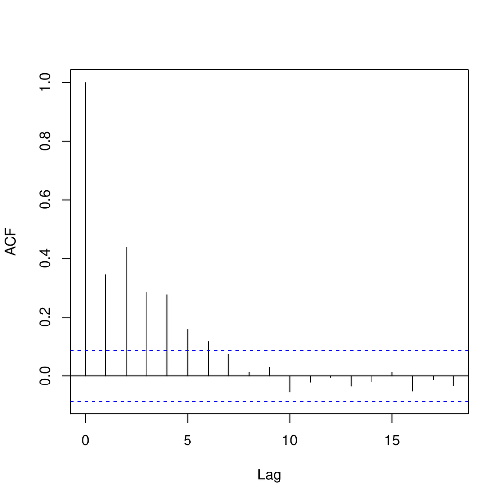

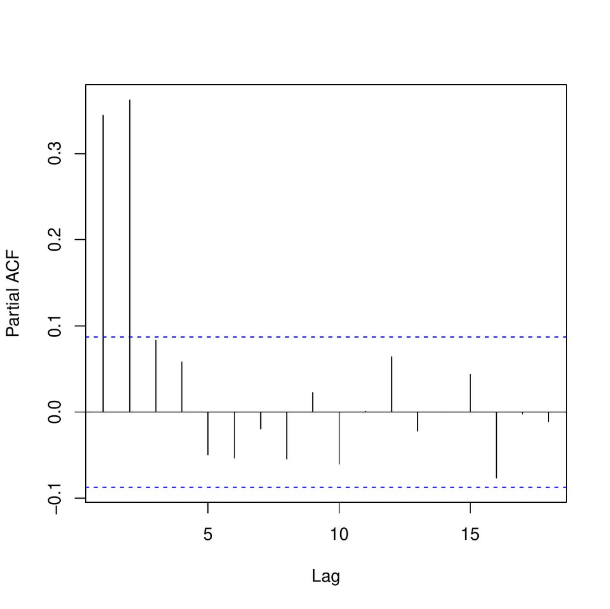

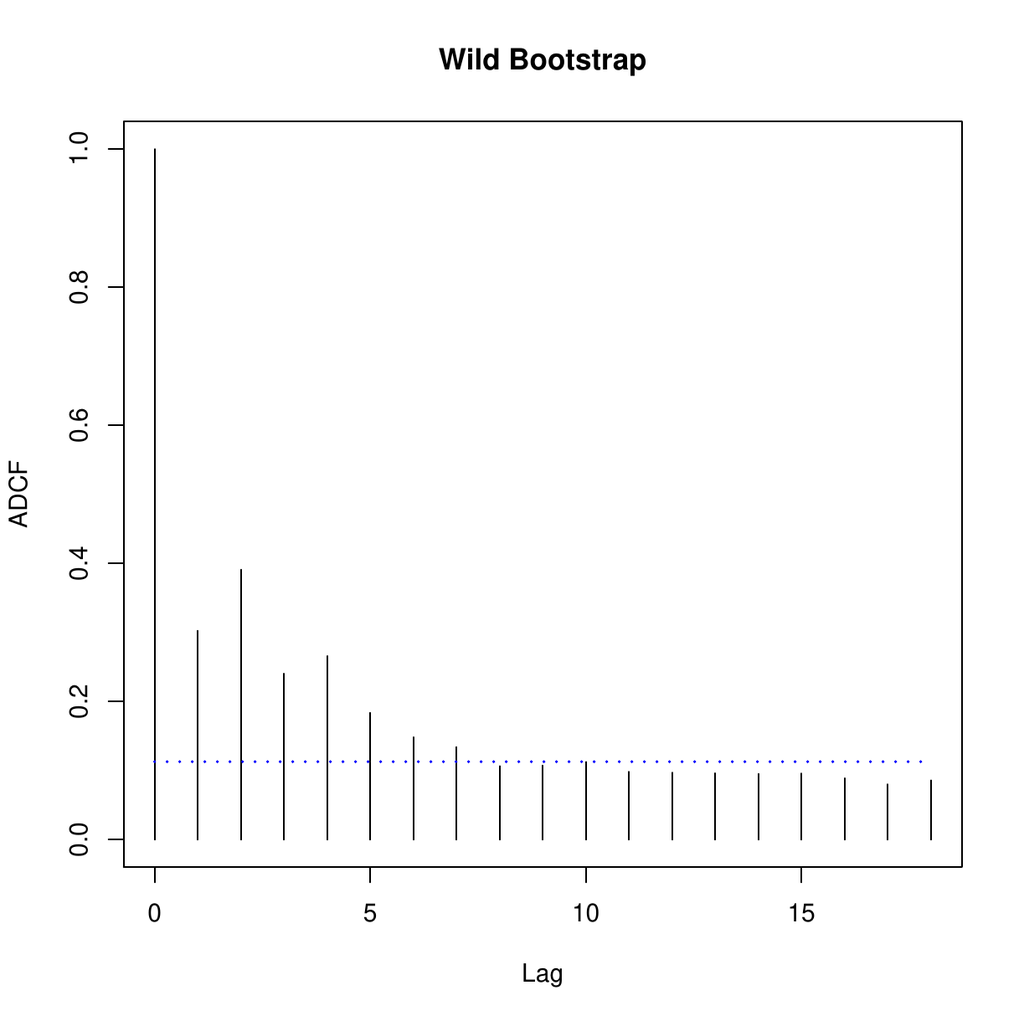

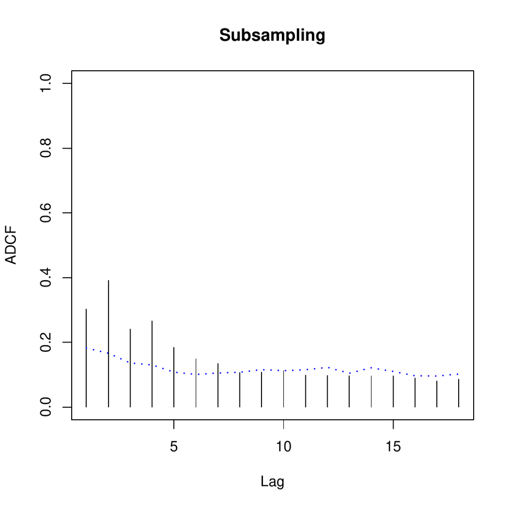

Figure 1: Sample ACF, PACF and ADCF plots of the mortality residuals of model .

The plots shown in Figure 1 suggest an AR(2) process for the residuals. The new fit is
$$\begin{aligned}
\label{eq:regr2}
\widehat{M}_t &= 3075.15 - 1.517_{(0.423)}t - 0.019_{(0.050)}(T_t - T.) \nonumber \\
&\phantom{=}+ 0.015_{(0.002)}(T_t - T.)^2 + 0.155_{(0.027)}P_t,
\end{aligned} \tag{19}$$
where the standard errors of the estimators are given in parentheses. The above model fit was derived by using the `arima()` function of R. The correlation plots for the residuals from the new model (19) are shown in Figure 2 indicating that there is no serial dependence.

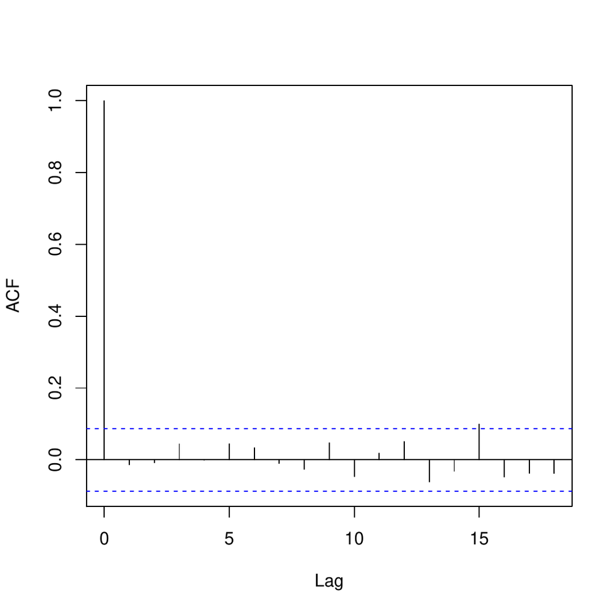

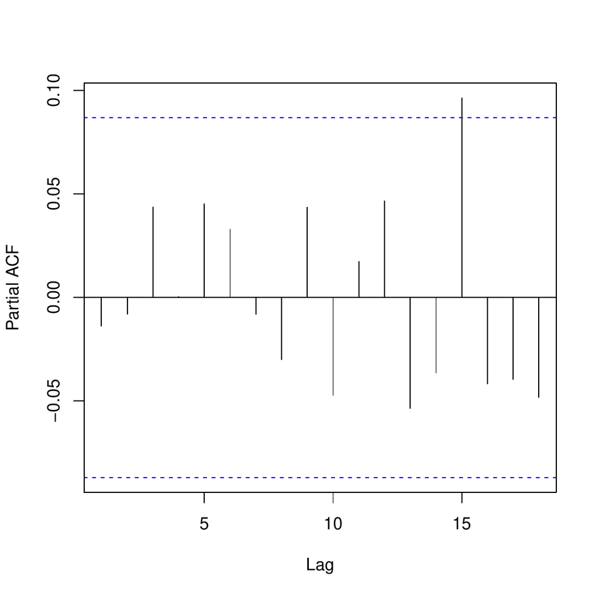

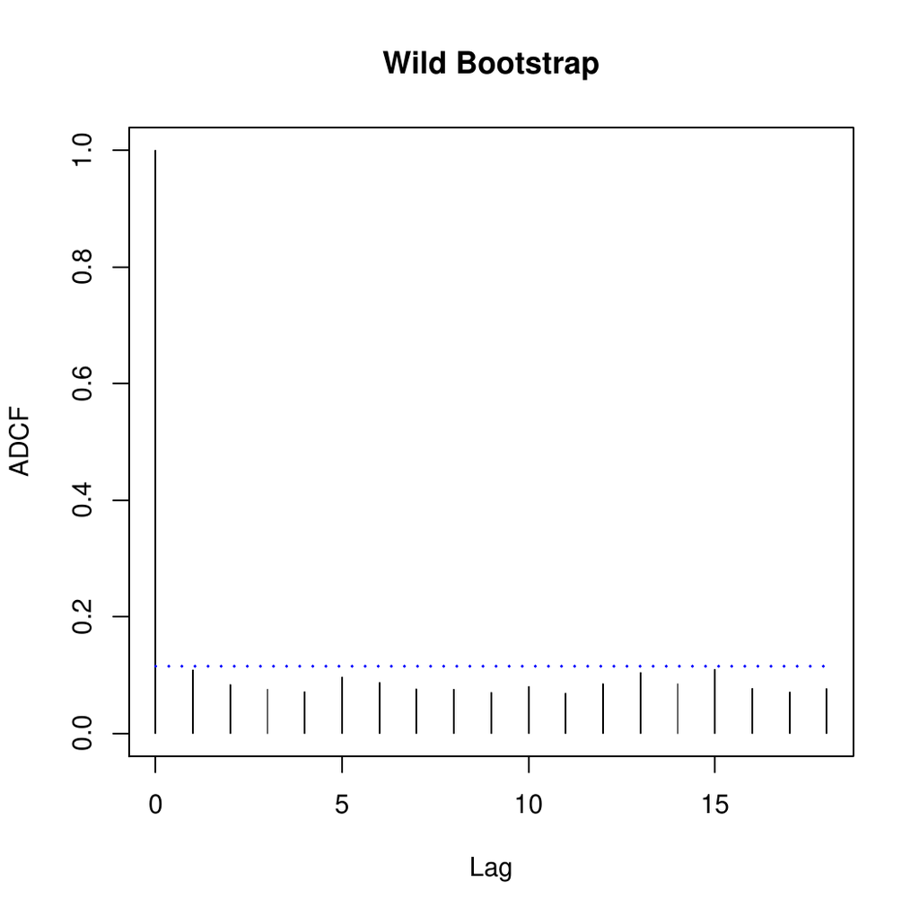

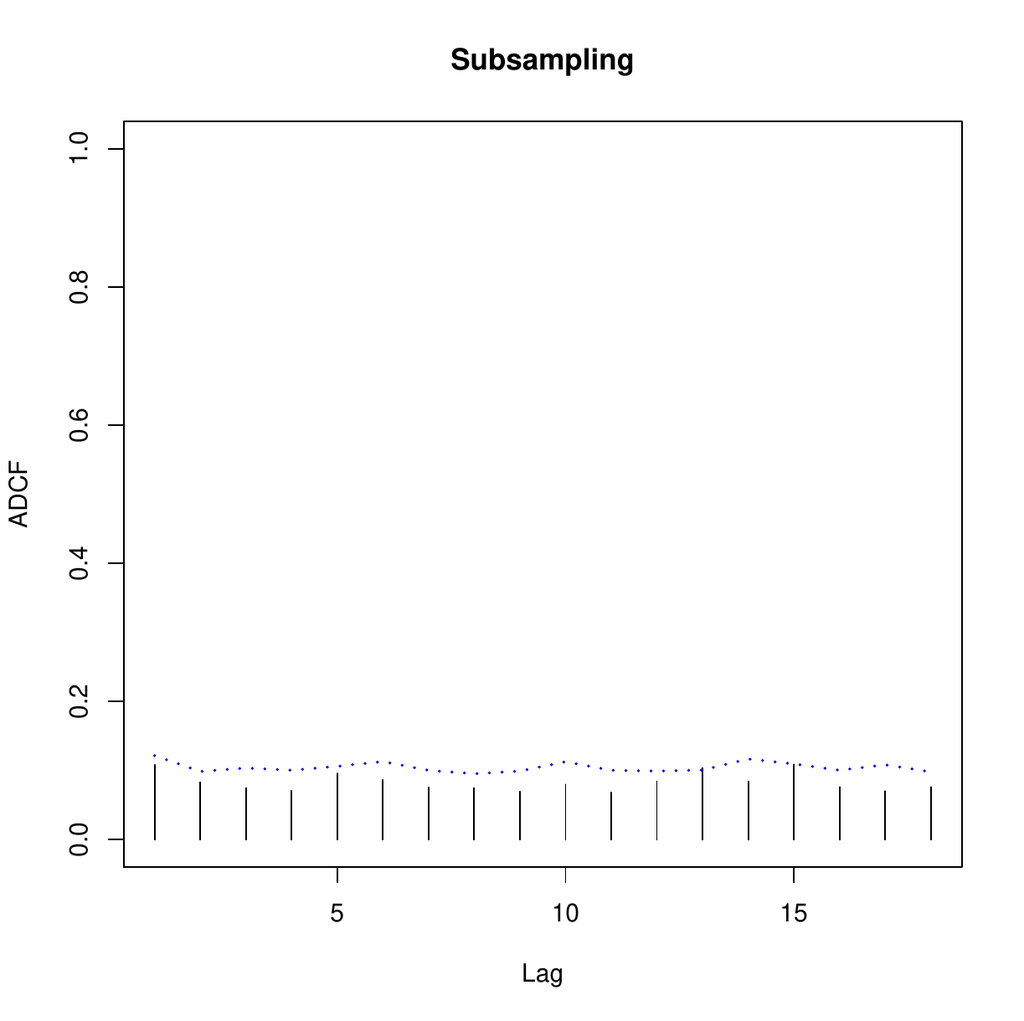

Figure 2: Sample ACF, PACF and ADCF plots of the mortality residuals of model indicating that the new residuals can be taken as white noise.

The calls for both model fits and their diagnostic plots are given below. ADCF plots (lower plots of Figures 1 and 2) are constructed using both resampling schemes explained in the previous section: independent wild bootstrap (with $b=499$ replications) and subsampling.

```r
temp <- tempr - mean(tempr)  # center temperature
temp2 <- temp^2
trend <- time(cmort)
fit <- lm(cmort ~ trend + temp + temp2 + part, na.action = NULL)
Residuals <- as.numeric(resid(fit))
##Correlation plots
acf(Residuals, lag.max = 18,main = "")
pacf(Residuals, lag.max = 18,main = "")
ADCFplot(Residuals, MaxLag = 18, main = "Wild Bootstrap", method = "Wild")
ADCFplot(Residuals, MaxLag = 18, main = "Subsampling", method = "Subsampling")

fit2 <- arima(cmort, order =c(2, 0, 0), xreg = cbind(trend, temp, temp2, part))
Residuals2 <- as.numeric(residuals(fit2))
##Correlation plots
acf(Residuals2, lag.max = 18, main = "")
pacf(Residuals2, lag.max = 18, main = "")
ADCFplot(Residuals2, MaxLag = 18, main = "Wild Bootstrap", method = "Wild")
ADCFplot(Residuals2, MaxLag = 18, main = "Subsampling", method = "Subsampling")
```

To formally confirm the absence of any serial dependence among the new residuals of model (19), as shown in Figure 2, we perform univariate tests of independence based on the test statistic $T_n$ given in (14). We use the `UnivTest()` function from our package with argument `testType = "covariance"` (default option). In order to examine the effect of using different bandwidths, we choose $p = \left[3n^\lambda\right]$ for $\lambda=0.1$, $0.2$ and $0.3$, that is $p=6$, $11$, and $20$, and we apply Bartlett kernel. The resulting $p$-values are $0.118$, $0.170$ and $0.208$ respectively suggesting acceptance of independence. We calculated $p$-values for $b=499$ independent wild bootstrap replications. The bootstrap procedure can be computed on multiple cores simultaneously by using the argument `parallel = TRUE` (they take about 10, 14 and 23 seconds respectively on a standard laptop with Intel Core i5 system and CPU 2.30 GHz):

```r
UnivTest(Residuals2, type = "bartlett", p = 6, b = 499, parallel = TRUE)

##         Univariate test of independence based on distance covariance
##
## data:  Residuals2, kernel type: bartlett, bandwidth=6, boot replicates 499
## Tn = 67.7344, p-value = 0.118

UnivTest(Residuals2, type = "bartlett", p = 11, b = 499, parallel = TRUE)

##         Univariate test of independence based on distance covariance
##
## data:  Residuals2, kernel type: bartlett, bandwidth=11, boot replicates 499
## Tn = 125.6674, p-value = 0.170

UnivTest(Residuals2, type = "bartlett", p = 20, b = 499, parallel = TRUE)

##         Univariate test of independence based on distance covariance
##
## data:  Residuals2, kernel type: bartlett, bandwidth=20, boot replicates 499
## Tn = 225.9266, p-value = 0.208
```

We compare the proposed test statistic with other test statistics to check its performance. In particular, we consider the Box-Pierce (Box and D. A. Pierce 1970) test statistic
$$BP = n\sum_{j=1}^{p}{\hat{\rho}^2(j)},$$
the Ljung-Box (Ljung and G. E. P. Box 1978) test statistic
$$LB = n(n+2)\sum_{j=1}^{p}{(n-j)^{-1}\hat{\rho}^2(j)},$$
the test statistic proposed by Hong (1996)
$$T_n^{(1)} = n\sum_{j=1}^{n-1}{k^2(j/p)\hat{\rho}^2(j)}$$
and the test statistic $T_n^{(2)}$ proposed by Hong (1999) defined in (13) with $\mathcal{W}(u,v) = \Phi(u)\Phi(v)$, and $\Phi(\cdot)$ being the cumulative distribution function of standard normal. For the aforestated bandwidth values, all these alternative test statistic give large $p$-values indicating the absence of any serial dependence among the new residuals. More precisely, BP and LB give $0.848$, $0.906$, $0.170$ and $0.844$, $0.901$, $0.142$ respectively. BP and LB based tests are performed in R by the function `Box.test()` as follows:

```r
box1 <- Box.test(Residuals2, lag = 6)
box2 <- Box.test(Residuals2, lag = 11)
box3 <- Box.test(Residuals2, lag = 20)
ljung1 <- Box.test(Residuals2, lag = 6, type = "Ljung")
ljung2 <- Box.test(Residuals2, lag = 11, type = "Ljung")
ljung3 <- Box.test(Residuals2, lag = 20, type = "Ljung")
```

The $p$-values obtained by $T_n^{(1)}$ are $0.896$, $0.930$ and $0.870$ respectively. $T_n^{(2)}$ gives the following $p$-values: $0.854$, $0.752$ and $0.504$ respectively. $T_n^{(1)}$ and $T_n^{(2)}$ are calculated by employing the Bartlett kernel. These $p$-values are calculated for $b=499$ ordinary bootstrap replications. The R functions for constructing these test statistics are beyond the scope of this paper and are available from the authors upon request.